# BSPv2

Aleksander Nitka

25/09/2018

## List matlab files in directory

```r
# Change that to wherever your data is
matdir = "/Users/aleksandernitka/OneDrive\ -\ The\ University\ of\ Nottingham/Lehigh_2018/Data/matlab_data"

files.mat = list.files(path = matdir, pattern = "\\.mat$")
print(files.mat)
```

```
##  [1] "BSPv2_1_block1_cond2.mat"  "BSPv2_1_block2_cond0.mat"
##  [3] "BSPv2_1_block3_cond1.mat"  "BSPv2_12_block1_cond1.mat"
##  [5] "BSPv2_12_block2_cond0.mat" "BSPv2_12_block3_cond2.mat"
##  [7] "BSPv2_13_block1_cond2.mat" "BSPv2_13_block2_cond1.mat"
##  [9] "BSPv2_13_block3_cond0.mat" "BSPv2_14_block1_cond1.mat"
## [11] "BSPv2_14_block2_cond0.mat" "BSPv2_14_block3_cond2.mat"
## [13] "BSPv2_15_block1_cond2.mat" "BSPv2_15_block2_cond1.mat"
## [15] "BSPv2_15_block3_cond0.mat" "BSPv2_16_block1_cond0.mat"
## [17] "BSPv2_16_block2_cond1.mat" "BSPv2_16_block3_cond2.mat"
## [19] "BSPv2_17_block1_cond1.mat" "BSPv2_17_block2_cond0.mat"
## [21] "BSPv2_17_block3_cond2.mat" "BSPv2_18_block1_cond1.mat"
## [23] "BSPv2_18_block2_cond2.mat" "BSPv2_18_block3_cond0.mat"
## [25] "BSPv2_19_block1_cond0.mat" "BSPv2_19_block2_cond1.mat"
## [27] "BSPv2_19_block3_cond2.mat" "BSPv2_2_block1_cond0.mat"
## [29] "BSPv2_2_block2_cond2.mat"  "BSPv2_2_block3_cond1.mat"
## [31] "BSPv2_20_block1_cond1.mat" "BSPv2_20_block2_cond0.mat"
## [33] "BSPv2_20_block3_cond2.mat" "BSPv2_3_block1_cond0.mat"
## [35] "BSPv2_3_block2_cond2.mat"  "BSPv2_3_block3_cond1.mat"
## [37] "BSPv2_4_block1_cond0.mat"  "BSPv2_4_block2_cond1.mat"
## [39] "BSPv2_4_block3_cond2.mat"  "BSPv2_5_block1_cond1.mat"
## [41] "BSPv2_5_block2_cond2.mat"  "BSPv2_5_block3_cond0.mat"
## [43] "BSPv2_6_block1_cond2.mat"  "BSPv2_6_block2_cond1.mat"
## [45] "BSPv2_6_block3_cond0.mat"
```

## Load files into a one data frame

```r
for (i in 1:length(files.mat)) {

    # Extract details from file name
    exp = strsplit(files.mat[i], "_")[[1]][1]
    ss = strsplit(files.mat[i], "_")[[1]][2]
    block = strsplit(files.mat[i], "_")[[1]][3]
    cond = strsplit(strsplit(files.mat[i], "_")[[1]][4], '[.]')[[1]][1]

    # Read mat file
    dat = readMat( paste(matdir, files.mat[i], sep = "/"))

    # Extract data from mat to R
    # searchRT - rection time to non-porbe trials, 0 if probe trial but 0 also if no response
    # targetletters - no of accurately reported letters on target side
    # distletters - no of accurately reported letters on non-target side
    # probe - logical if trial was a probe or not
    # SearchRespCode - 38 is UpArrow and 40 is DownArrow



    tmp = as.data.frame(cbind(t(dat$searchRT),
                              t(dat$searchRespCode),
                              t(dat$searchacc),
                              t(dat$targletters),
                              t(dat$distletters),
                              dat$probe,
                              t(dat$FA),
                              t(dat$colorcue),
                              exp, ss, block, cond
                              ))

    names(tmp) = c('RT', 'SearchRespCode', 'SearchAccuracy', 'TargLetters', 'DistLetters', 'ProbeTrial', 'FA',
                   'ColorCue', 'Exp', 'SS', 'Block', 'Cond')

    # Extract orientation codes
    orient = as.data.frame(dat$Orient)
    names(orient) = c('orient01', 'orient02', 'orient03', 'orient04',
                      'orient05', 'orient06', 'orient07', 'orient08',
                      'orient09', 'orient10', 'orient11', 'orient12')

    #tmp = cbind(tmp, orient)

    if (i == 1){
        # Create main data frame by copying the tmp
        BSPv2 = tmp
        print('BSPv2 data frame created')
        print(sprintf('Added ss %s, %s, %s to BSPv2', ss, block, cond))
        remove(tmp, block, cond, exp, ss, orient, dat)
    }
    else {
        # bind main data frame and tmp
        BSPv2 = rbind(BSPv2, tmp)
        print(sprintf('Added ss %s, %s, %s to BSPv2', ss, block, cond))
        remove(tmp, block, cond, exp, ss, orient, dat)

    }

}
```

```
## [1] "BSPv2 data frame created"
## [1] "Added ss 1, block1, cond2 to BSPv2"
## [1] "Added ss 1, block2, cond0 to BSPv2"
## [1] "Added ss 1, block3, cond1 to BSPv2"
## [1] "Added ss 12, block1, cond1 to BSPv2"
## [1] "Added ss 12, block2, cond0 to BSPv2"
## [1] "Added ss 12, block3, cond2 to BSPv2"
## [1] "Added ss 13, block1, cond2 to BSPv2"
## [1] "Added ss 13, block2, cond1 to BSPv2"
## [1] "Added ss 13, block3, cond0 to BSPv2"
## [1] "Added ss 14, block1, cond1 to BSPv2"
## [1] "Added ss 14, block2, cond0 to BSPv2"
## [1] "Added ss 14, block3, cond2 to BSPv2"
## [1] "Added ss 15, block1, cond2 to BSPv2"
## [1] "Added ss 15, block2, cond1 to BSPv2"
```

[output cut: 31 more lines]

## Do some data manipulations, prep for mean analysis

```r
# data type must be changed from integer to numeric, but converting directly changes the values,
# must convert to string and then to numeric to keep the actual values
BSPv2$RT = as.numeric(as.character(BSPv2$RT))
BSPv2$TargLetters = as.numeric(BSPv2$TargLetters)
BSPv2$DistLetters = as.numeric(BSPv2$DistLetters)
BSPv2$TrialType = 'RT'
BSPv2$TrialType[BSPv2$ProbeTrial == 1] = 'PR'
BSPv2$SS = as.numeric(as.character(unique(BSPv2$SS)))

# If RT = 0 and trial != Probe then it was a timeOut
# need to mark those as otherwise 0 will be counted towards the mean
BSPv2$timeOut = 0
BSPv2$timeOut[BSPv2$RT == 0 & BSPv2$ProbeTrial == 0] = 1

# Get subject IDs
SSid = unique(BSPv2$SS)

# Create a DF for means
means_BSPv2 = data.frame(matrix(nrow = length(SSid)*3, ncol = 5))
names(means_BSPv2) = c('SS', 'Cond', 'mRT', 'LettersTarget', 'LettersDistractor')
means_BSPv2$SS = SSid
means_BSPv2$Cond = c(rep('cond0',length(SSid)), rep('cond1',length(SSid)), rep('cond2',length(SSid)))
means_BSPv2$Accuracy = NA # 1 means correct. 0 mean incorrect and 2 means no response or participant has a probe trial
```

## Extract means

```r
for (i in 1:nrow(means_BSPv2)){

    # isolate 1 ss data
    d = subset(BSPv2, BSPv2$SS == means_BSPv2$SS[i])
    # isolate rt trials
    r = subset(d, d$TrialType == 'RT')
    # isolate probe trials
    p = subset(d, d$TrialType == 'PR')

    # calculate mean RT form a subset of condition, exclude Timed out trials and Incorrect responses
    means_BSPv2$mRT[i] = mean( subset( r$RT, r$Cond == means_BSPv2$Cond[i] & r$timeOut == 0 & r$SearchAccuracy == 1 ))

    # calculate mean Accuracy for condition, form: (timeout + inaccurate) / all trials
    means_BSPv2$Accuracy[i] = 1 - (nrow(subset(r, r$SearchAccuracy != 1 & r$Cond == means_BSPv2$Cond[i]))/nrow(subset(r, r$Cond == means_BSPv2$Cond[i])))

    # calcualte the mean number of letters reported on Target side in each probe trial
    means_BSPv2$LettersTarget[i] = mean(subset( p$TargLetters, p$Cond == means_BSPv2$Cond[i] ))

    # do the same for distracotr letters
    means_BSPv2$LettersDistractor[i] = mean(subset( p$DistLetters, p$Cond == means_BSPv2$Cond[i] ))



}

# Make sure that data types as good
means_BSPv2$Cond = as.factor(means_BSPv2$Cond)
means_BSPv2$LettersTarget = as.numeric(means_BSPv2$LettersTarget)
means_BSPv2$LettersDistractor = as.numeric(means_BSPv2$LettersDistractor)


# Probe trials, Create Difference Index = Target - Distractor

means_BSPv2$LettersDiff = means_BSPv2$LettersTarget - means_BSPv2$LettersDistractor
```

## Individual Means

| SS | Cond | mRT | LettersTarget | LettersDistractor | Accuracy | LettersDiff |
| --- | --- | --- | --- | --- | --- | --- |
| 1 | cond0 | 1.737111 | 2.238095 | 2.142857 | 0.8823529 | 0.0952381 |
| 12 | cond0 | 1.565233 | 2.666667 | 2.000000 | 0.8500000 | 0.6666667 |
| 13 | cond0 | 1.819340 | 1.750000 | 2.312500 | 0.8852459 | -0.5625000 |
| 14 | cond0 | 1.773017 | 2.484849 | 1.909091 | 0.9193548 | 0.5757576 |
| 15 | cond0 | 1.992718 | 2.066667 | 2.266667 | 0.8153846 | -0.2000000 |
| 16 | cond0 | 1.788464 | 2.214286 | 2.357143 | 0.9104478 | -0.1428571 |
| 17 | cond0 | 1.878958 | 2.393939 | 2.272727 | 0.8750000 | 0.1212121 |
| 18 | cond0 | 1.826503 | 2.483871 | 2.096774 | 0.8787879 | 0.3870968 |
| 19 | cond0 | 1.895461 | 1.880000 | 2.280000 | 0.8472222 | -0.4000000 |
| 2 | cond0 | 1.864198 | 2.111111 | 2.305556 | 0.8095238 | -0.1944444 |
| 20 | cond0 | 1.797548 | 2.000000 | 2.272727 | 0.8636364 | -0.2727273 |
| 3 | cond0 | 2.003652 | 2.185185 | 2.148148 | 0.8055556 | 0.0370370 |
| 4 | cond0 | 1.777396 | 2.354839 | 1.870968 | 0.7846154 | 0.4838710 |
| 5 | cond0 | 1.834614 | 2.142857 | 2.285714 | 0.8360656 | -0.1428571 |
| 6 | cond0 | 1.783754 | 2.096774 | 2.225807 | 0.8923077 | -0.1290323 |
| 1 | cond1 | 1.556350 | 2.722222 | 1.555556 | 0.8666667 | 1.1666667 |
| 12 | cond1 | 1.527664 | 2.413793 | 1.689655 | 0.9104478 | 0.7241379 |
| 13 | cond1 | 1.548140 | 2.281250 | 1.656250 | 0.9062500 | 0.6250000 |
| 14 | cond1 | 1.763101 | 2.128205 | 1.948718 | 0.8448276 | 0.1794872 |
| 15 | cond1 | 1.721742 | 2.105263 | 1.842105 | 0.9491525 | 0.2631579 |
| 16 | cond1 | 1.778432 | 2.200000 | 1.840000 | 0.9027778 | 0.3600000 |
| 17 | cond1 | 1.696948 | 2.312500 | 1.718750 | 0.9062500 | 0.5937500 |
| 18 | cond1 | 1.716949 | 2.357143 | 1.750000 | 0.8529412 | 0.6071429 |
| 19 | cond1 | 1.709725 | 2.769231 | 1.564103 | 0.9473684 | 1.2051282 |
| 2 | cond1 | 1.566890 | 2.342105 | 1.842105 | 0.8947368 | 0.5000000 |
| 20 | cond1 | 1.666259 | 2.280000 | 1.680000 | 0.8857143 | 0.6000000 |
| 3 | cond1 | 1.621925 | 2.533333 | 1.633333 | 0.9076923 | 0.9000000 |
| 4 | cond1 | 1.676746 | 2.625000 | 1.468750 | 0.9218750 | 1.1562500 |
| 5 | cond1 | 1.547659 | 2.281250 | 1.625000 | 0.9062500 | 0.6562500 |
| 6 | cond1 | 1.657899 | 2.480000 | 1.680000 | 0.8873239 | 0.8000000 |
| 1 | cond2 | 1.293611 | 2.870968 | 1.161290 | 0.9264706 | 1.7096774 |
| 12 | cond2 | 1.242669 | 3.000000 | 1.241379 | 0.9571429 | 1.7586207 |
| 13 | cond2 | 1.416916 | 3.027778 | 1.333333 | 0.9841270 | 1.6944444 |
| 14 | cond2 | 1.281384 | 2.937500 | 1.156250 | 0.9218750 | 1.7812500 |
| 15 | cond2 | 1.429838 | 3.064516 | 1.225807 | 0.9846154 | 1.8387097 |
| 16 | cond2 | 1.415566 | 3.238095 | 1.190476 | 0.9259259 | 2.0476190 |
| 17 | cond2 | 1.340420 | 2.840000 | 1.080000 | 0.9142857 | 1.7600000 |
| 18 | cond2 | 1.327880 | 3.000000 | 1.392857 | 0.9402985 | 1.6071429 |
| 19 | cond2 | 1.384125 | 3.000000 | 1.290323 | 0.9843750 | 1.7096774 |
| 2 | cond2 | 1.390078 | 3.230769 | 1.179487 | 0.9636364 | 2.0512821 |
| 20 | cond2 | 1.394467 | 3.115385 | 1.269231 | 0.9411765 | 1.8461538 |
| 3 | cond2 | 1.323054 | 2.972222 | 1.194444 | 0.9655172 | 1.7777778 |
| 4 | cond2 | 1.266849 | 2.733333 | 1.533333 | 0.9545455 | 1.2000000 |
| 5 | cond2 | 1.369688 | 2.935484 | 1.161290 | 0.8769231 | 1.7741935 |
| 6 | cond2 | 1.322927 | 3.151515 | 1.242424 | 0.9206349 | 1.9090909 |

## Fast results - descriptives

### RT analysis

Performed for N = 15. Mean RT for **‘cond0’** was 1.8225312 (SD = 0.1046953), for **‘cond1’** it was 1.6504285 (SD = 0.083669) and for **‘cond2’** it was 1.3466314 (SD = 0.0588449).

Accuracy, the mean accuracy for **‘cond0’** was M = 0.8570334 (SD = 0.0402931) and for the **‘cond1’** condition M = 0.8993516, SD = (0.0295046) and M = M = 0.9441033, SD = (0.0305843) for **‘cond2’**.

### Probe analysis.

On **‘cond0’** trials participants reported M = 2.2046093 (SD = 0.2430671) letters on the Target Side and M = 2.1831119 (SD = 0.151928) on Distractor Side. During the **‘cond1’** trials participants reported M = 2.3887531 (SD = 0.2016794) letters on the Target Side and M = 1.6996217 (SD = 0.1282846) on Distractor Side. Finally, for the **‘cond2’** trials participants reported M = 3.0078377 (SD = 0.1394959) letters on the Target Side and M = 1.2434617 (SD = 0.1117175) on Distractor Side.

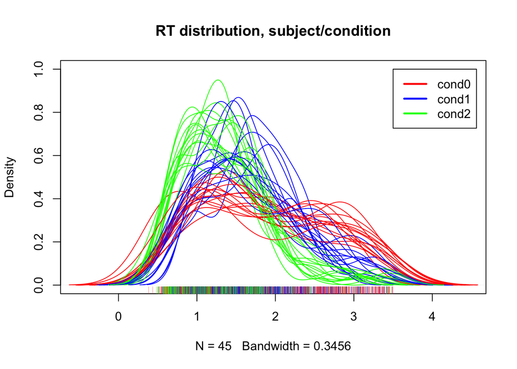

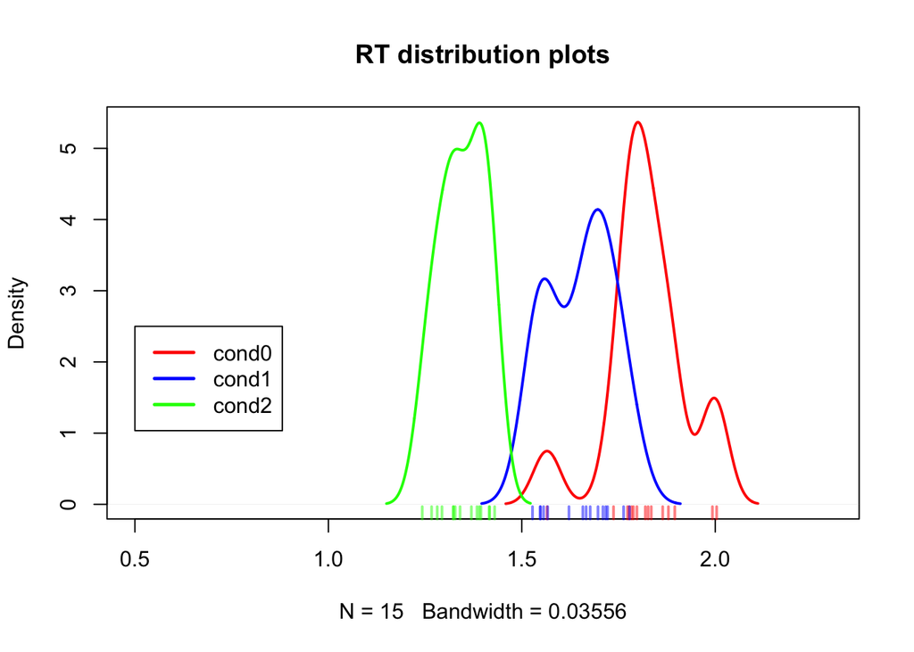

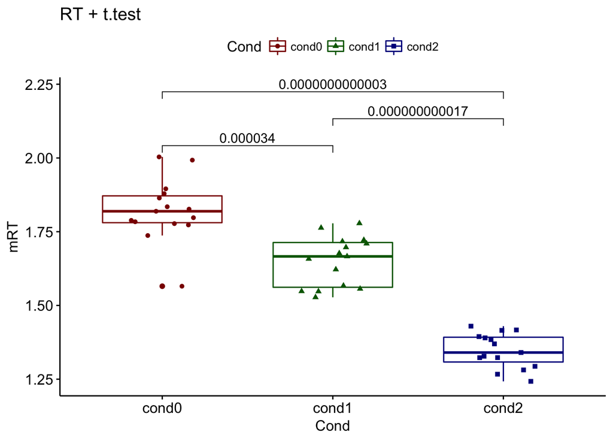

```r
#ggplot(data = means_BSPv2, aes(Cond, mRT)) + geom_point(color="skyblue") + stat_summary(fun.y=mean,geom="line",lwd=1,aes(group=1))

my_test = list( c("cond0", "cond1"), c("cond1", "cond2"), c("cond0", "cond2") )

rt_plg = ggboxplot(means_BSPv2, x = "Cond", y = "mRT",
                color = "Cond", palette =c("dark red", "dark green", "dark blue"),
                add = "jitter", shape = "Cond") + stat_compare_means(comparisons = my_test, method = "t.test") + ggtitle("RT + t.test")

rt_plg
```

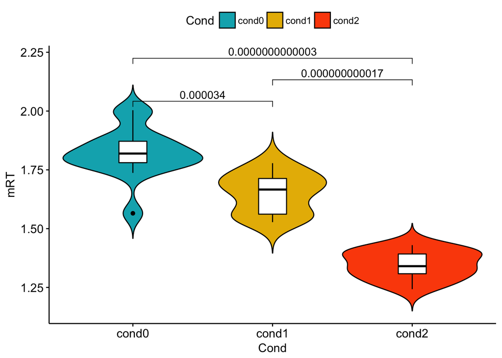

```r
rt_violin = ggviolin(means_BSPv2, x = "Cond", y = "mRT", fill = "Cond",
         palette = c("#00AFBB", "#E7B800", "#FC4E07"),
         add = "boxplot", add.params = list(fill = "white"))+ stat_compare_means(comparisons = my_test, method = 't.test')

rt_violin
```

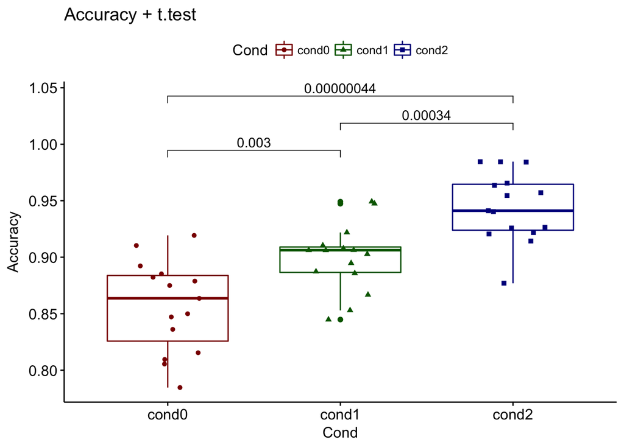

```r
my_test = list( c("cond0", "cond1"), c("cond1", "cond2"), c("cond0", "cond2") )

acc_plg = ggboxplot(means_BSPv2, x = "Cond", y = "Accuracy",
                color = "Cond", palette =c("dark red", "dark green", "dark blue"),
                add = "jitter", shape = "Cond") + stat_compare_means(comparisons = my_test, method = "t.test") + ggtitle("Accuracy + t.test")
acc_plg
```

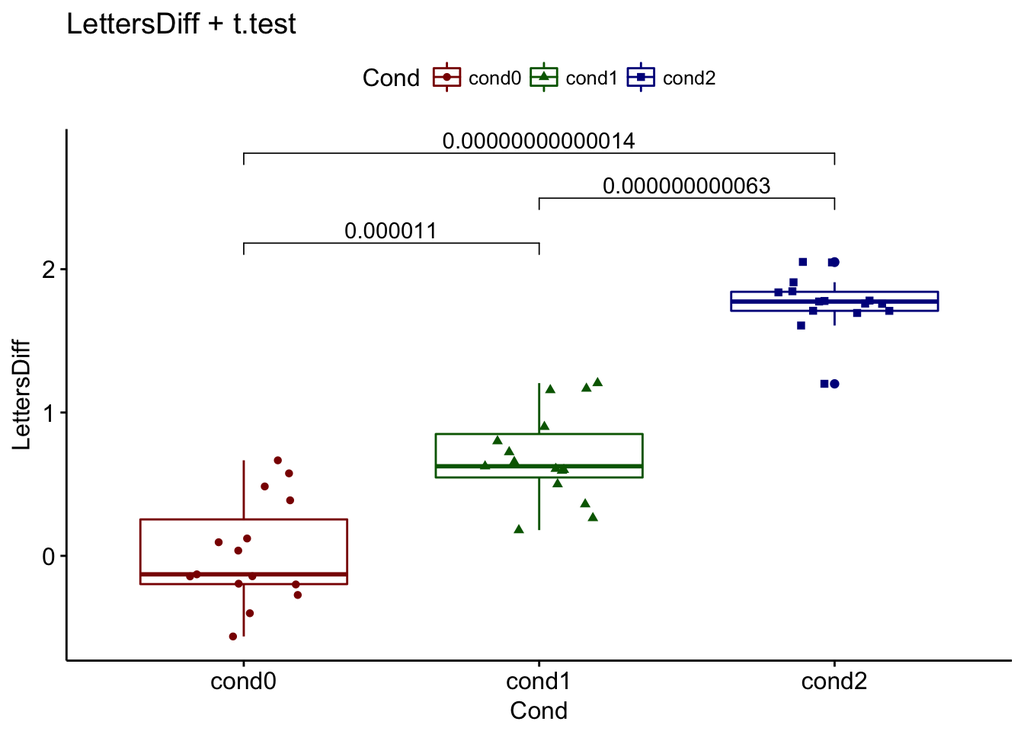

```r
my_test = list( c("cond0", "cond1"), c("cond1", "cond2"), c("cond0", "cond2") )

lettDiff_plg = ggboxplot(means_BSPv2, x = "Cond", y = "LettersDiff",
                color = "Cond", palette =c("dark red", "dark green", "dark blue"),
                add = "jitter", shape = "Cond") + stat_compare_means(comparisons = my_test, method = "t.test") + ggtitle("LettersDiff + t.test")
lettDiff_plg
```

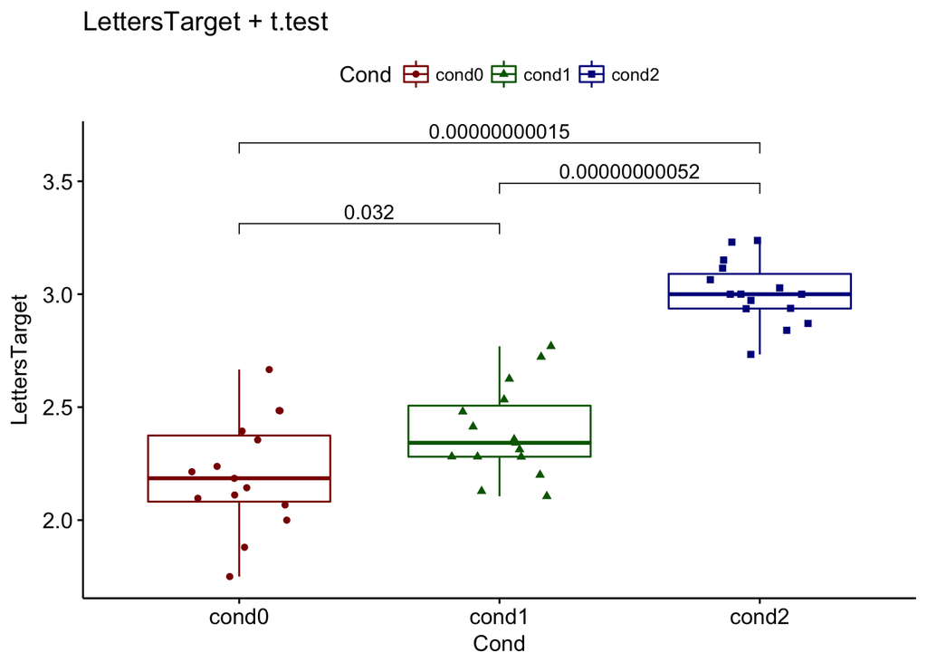

```r
lettTar_plg = ggboxplot(means_BSPv2, x = "Cond", y = "LettersTarget",
                color = "Cond", palette =c("dark red", "dark green", "dark blue"),
                add = "jitter", shape = "Cond") + stat_compare_means(comparisons = my_test, method = "t.test") + ggtitle("LettersTarget + t.test")
lettTar_plg
```

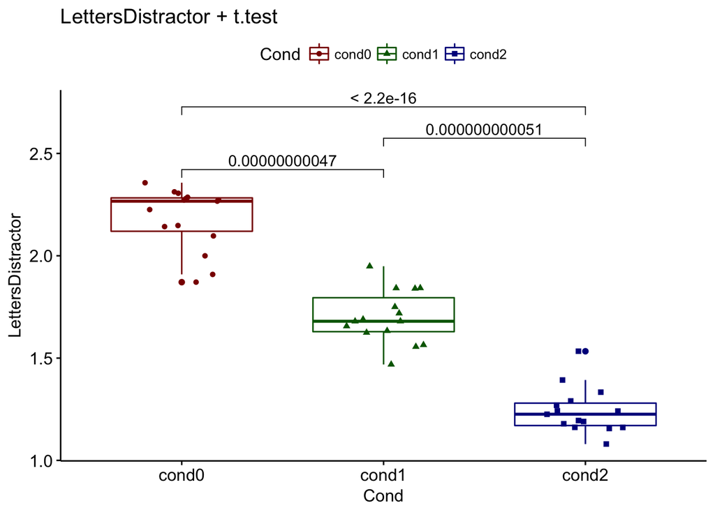

```r
lettDist_plg = ggboxplot(means_BSPv2, x = "Cond", y = "LettersDistractor",
                color = "Cond", palette =c("dark red", "dark green", "dark blue"),
                add = "jitter", shape = "Cond") + stat_compare_means(comparisons = my_test, method = "t.test") + ggtitle("LettersDistractor + t.test")
lettDist_plg
```

```r
## RT
# normality test - all RT data
rt_sw = shapiro.test(means_BSPv2$mRT)
# as above but for cond0, 1, 2
rt_sw_c0 = shapiro.test(means_BSPv2$mRT[means_BSPv2$Cond == 'cond0'])
rt_sw_c1 = shapiro.test(means_BSPv2$mRT[means_BSPv2$Cond == 'cond1'])
rt_sw_c2 = shapiro.test(means_BSPv2$mRT[means_BSPv2$Cond == 'cond2'])

# Bartlett Test of Homogeneity of Variances PARAMETIC
# From: http://www.instantr.com/2012/12/12/performing-bartletts-test-in-r/
# Bartlett’s test allows you to compare the variance of two or more samples to determine whether they are drawn from populations with equal variance. It is suitable for normally distributed data. The test has the null hypothesis that the variances are equal and the alterntive hypothesis that they are not equal.
# NS means we cannot reject the null hypothesis that the variance is the same for all treatment groups.
rt_bt = bartlett.test(mRT~Cond, data=means_BSPv2)

# Levene's test (does the same as Bartlett), if NS homescedascity can be assumed.
rt_lt = leveneTest(mRT~Cond, data=means_BSPv2)
rt_lt_p = rt_lt$`Pr(>F)`[1] # because of stupid packing of this value

# Figner-Killeen Test of Homogeneity of Variances NON-PARAMETIC
# fligner.test(mRT~Cond, data=means_BSPv2)
```

### Assumptions testing, RT

For **normality** of data Shapiro-Wilk test was used. Normality can be assumed if the test is ns and so for all RT data it was p = 0.0309329, for a subset of **‘cond0’** RTs it as p = 0.2067814, for **‘cond1’** p = 0.2070537 and for the **‘cond2’** p = 0.5381294.

Next the assumption that **variances** of the populations from which different samples are drawn are equal. This was done with Bartlett Test of Homogeneity of Variances and Levene’s Test. If either of those tests comes out as ns it means we cannot reject the null hypothesis that the variance is the same for all treatment groups. Bartlett test had p = 0.1177068 and Levene’s had p = 0.4669794.

```r
rt_aov = aov(data = means_BSPv2, mRT ~ Cond)
summary(rt_aov)
```

```
##             Df Sum Sq Mean Sq F value              Pr(>F)
## Cond         2 1.7420  0.8710     122 <0.0000000000000002 ***
## Residuals   42 0.2999  0.0071
## ---
## Signif. codes:  0 '***' 0.001 '**' 0.01 '*' 0.05 '.' 0.1 ' ' 1
```

```r
# Run this for variances not equal:
#rt_aov_ow = oneway.test(data = means_BSPv2, mRT ~ Cond)
```